# Preliminary impact evaluation of the Frailty Improvement Collaborative

## Overview

### Introduction

This document provides an overview of the preliminary impact evaluation of the Frailty Improvement Collaborative (FIC).

## Methodology

This evaluation uses a variation of Synthetic Difference In Differences (SDID), based on the method proposed by [Arkhangelsky, Athey, Hirshberg, Imbens and Wager (2021)](https://www.aeaweb.org/articles?id=10.1257/aer.20190159). The methodology underpinning this evaluation extends classic SDID from normally distributed outcomes to be able to function with counts and proportions (which do not follow the normal distribution).

SDID creates a counterfactual of what would have happened for each individual place affected by the FIC, and then compares this counterfactual outcome to what actually happened after the FIC was introduced. The counterfactual for what would have happened without the FIC is by constructed using a weighted average of places unaffected by the FIC. The weightings used to construct the weighted average are constructed to maximise the match between the affected place and the counterfactual before the intervention (the pre-period). A similar process is then repeated using the time periods - the period after the introduction of the FIC is constructed as a weighted average of the most similar periods before the introduction of the FIC.

This process comes with a certain amount of uncertainty, simply due to statistical variation and modelling inaccuracy. In this case that uncertainty is quantified by comparing the estimated impact across the places affected by the FIC to the estimated impact when the procedure is repeated in places which were not affected by the FIC (and therefore it is known that the true effect is zero).

## Impact evaluation outcomes

### Hospital admissions for people living with frailty

Hospital admissions by people living with frailty is defined as the number of unplanned admissions to hospital by patients with a HFRS of five or over at the time of admission.

In the period after the FIC was introduced, the average affected place, during the average month, had 2,420 hospital admissions by people living with frailty. It is estimated that without the FIC, the average affected place, during the average month, would have instead had 2,390 hospital admissions by people living with frailty.

A difference larger than this was observed in 48.8% of the placebo tests, indicating that this difference could be due to modelling uncertainty rather than any true impact of the FIC.

The chart below shows the actual number of hospital admissions by people living with frailty (in blue) relative to the estimated number of admissions that would have happened without the FIC (in red). The vertical black line indicates when the programme was introduced.

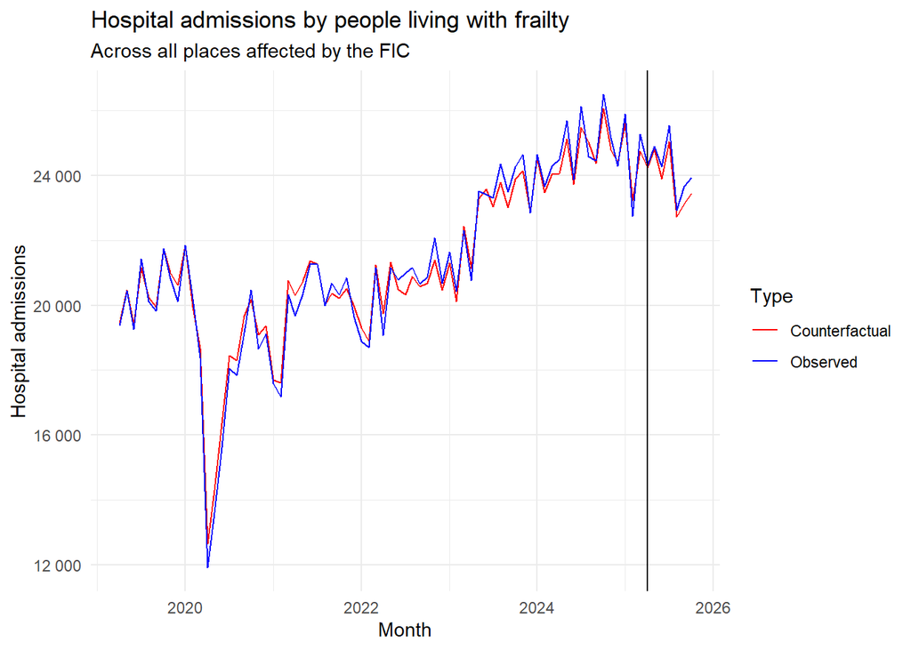

### Hospital re-admissions for people living with frailty within 28 days of discharge

Hospital readmissions for people living with frailty within 28 days of discharge is a count of the total number of unplanned admissions to hospital by patients with a HFRS of five or over at the time of admissions who also had a discharge within the preceding 28 days. It is worth noting that this definition also excludes patients with various conditions where treatment can involve repeated admission and discharge.

In the period after the FIC was introduced, the average affected place, during the average month, had 198 hospital readmissions by people living with frailty. It is estimated that without the FIC, the average affected place, during the average month, would have instead had 189 hospital readmissions by people living with frailty.

A difference larger than this was observed in 26.1% of the placebo tests, indicating that this difference could be due to modelling uncertainty rather than any true impact of the FIC.

The chart below shows the actual number of hospital readmissions by people living with frailty (in blue) relative to the estimated number of readmissions that would have happened without the FIC (in red). The vertical black line indicates when the programme was introduced.

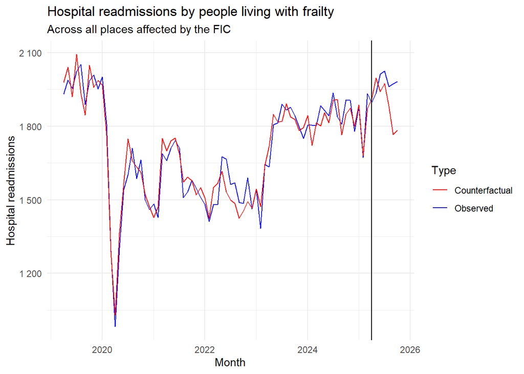

### Attendances to Emergency Departments for people living with frailty

Attendances to Emergency Departments (ED) for people living with frailty is defined as the number of unplanned attendances to ED by patients with a HFRS of five or over at the time of attendance.

In the period after the FIC was introduced, the average affected place, during the average month, had 1,500 ED admissions by people living with frailty. It is estimated that without the FIC, the average affected place, during the average month, would have instead had 1,490 ED admissions by people living with frailty.

A difference larger than this was observed in 90.4% of the placebo tests, indicating that this difference could be due to modelling uncertainty rather than any true impact of the FIC.

The chart below shows the actual number of ED admissions by people living with frailty (in blue) relative to the estimated number of admissions that would have happened without the FIC (in red). The vertical black line indicates when the programme was introduced.

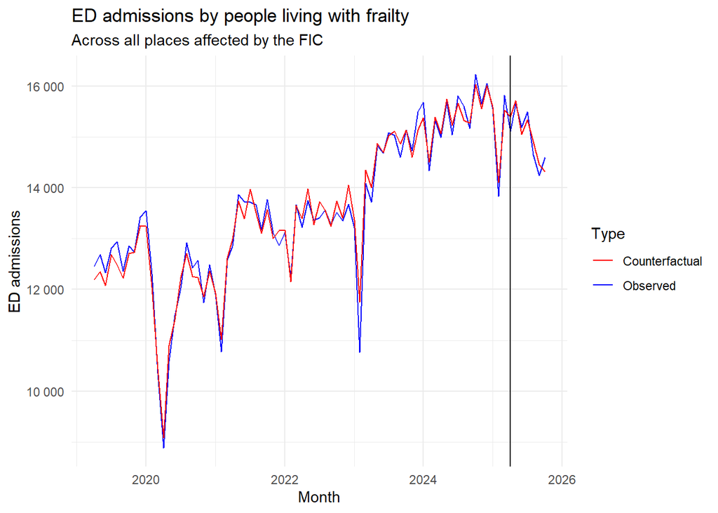

### Hospital conveyances for people living with frailty

Hospital conveyances for people living with frailty was defined as the number of ambulance conveyances to ED for patients with a HFRS of five or higher at attendance, as a proportion of the total number of attendances to ED by patients with a HFRS or five or higher at attendance.

In the period after the FIC was introduced, the average affected place, during the average month, had 1,500 attendances to ED by people living with frailty. Of these, 59.4% were conveyed by ambulance. It is estimated that without the FIC, the average affected place, during the average month, would have instead had 58% conveyed by ambulance.

A difference larger than this was observed in 5.76% of the placebo tests, indicating that this difference could be due to modelling uncertainty rather than any true impact of the FIC.

The chart below shows the actual percentage of ED admissions by people living with frailty which were conveyances by ambulance (in blue) relative to the estimated percentage of ED admissions by people living with frailty which were conveyances by ambulance that would have happened without the FIC (in red). The vertical black line indicates when the programme was introduced.

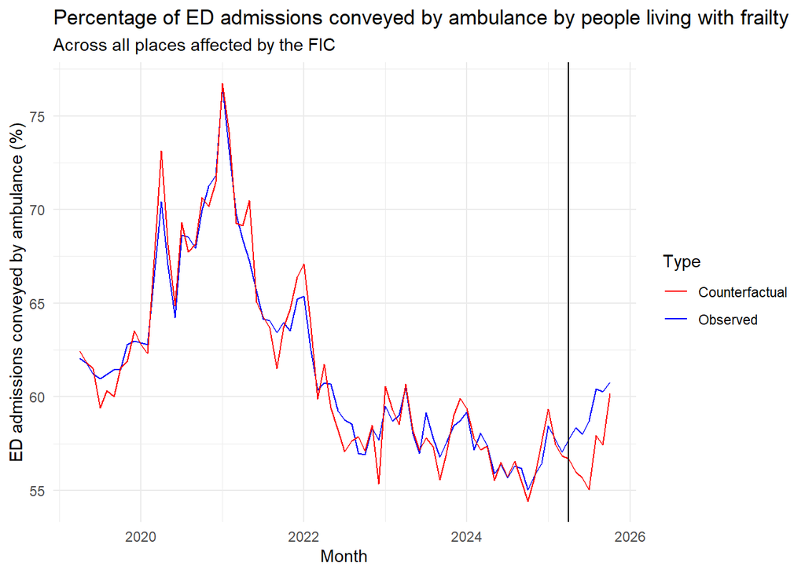

### Total bed days used by people living with frailty

Total bed days used by people living with frailty is the sum of completed days in hospital by patients with a HFRS of five or higher at the time of admissions.

The chart below shows the actual number total hospital days by people living with frailty (in blue) relative to the estimated number of hospital days that would have happened without the FIC (in red). The vertical black line indicates when the programme was introduced.

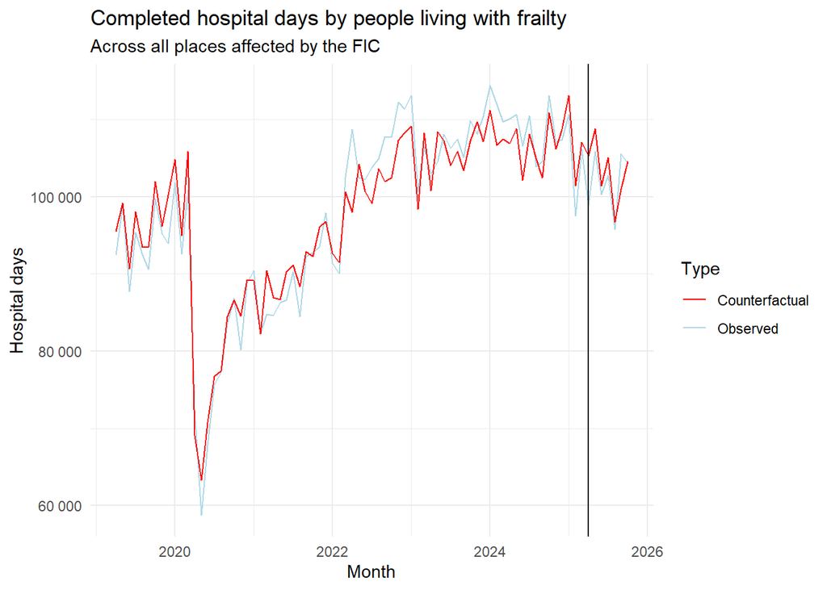

### Average length of stay for people living with frailty

The average length of stay for people living with frailty is the total number of completed days in hospital by patients with a HFRS of five or higher on admission, divided by the number of admissions to hospital by people with a HFRS of five or higher on admission.

The chart below shows the actual average hospital length of stay by people living with frailty (in blue) relative to the estimated number of hospital days that would have happened without the FIC (in red). The vertical black line indicates when the programme was introduced.

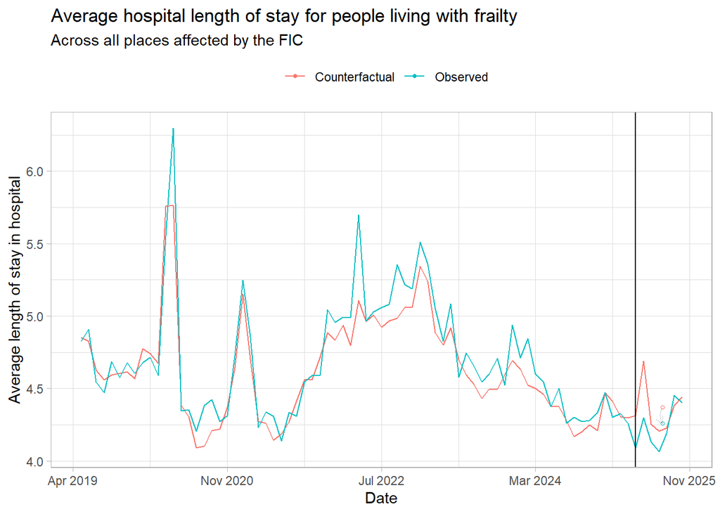

### Discharges to usual place of residence for people living with frailty

Discharges to usual place of residence was defined as the number of patients with a HFRS of five or higher on admission who were discharged to their usual place of residence, as a proportion of all discharged patients who had a HSF of five or higher on admission. Note that a number of patients were excluded from this analysis entirely due to having discharge location which was primarily caused by external circumstances - for example if their discharge location was a forced repatriation or was unknown.

In the period after the FIC was introduced, the average affected place, during the average month, had 2,360 discharges by people living with frailty. Of these, 97.2% were discharged to their usual place of residence. It is estimated that without the FIC, the average affected place, during the average month, would have instead had 97.3% were discharged to their usual place of residence.

A difference larger than this was observed in 91.96% of the placebo tests, indicating that this difference could be due to modelling uncertainty rather than any true impact of the FIC.

The chart below shows the actual percentage of people living with frailty who were discharged to their usual place of residence (in blue) relative to the estimated percentage of people living with frailty who were discharged to their usual place of residence that would have happened without the FIC (in red). The vertical black line indicates when the programme was introduced.

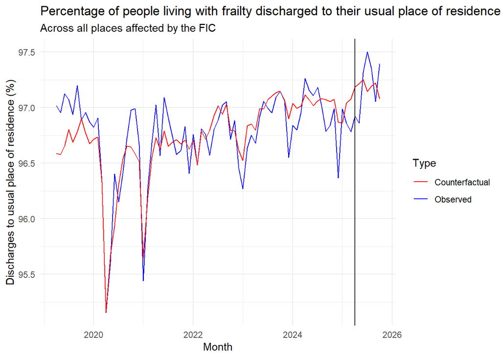

### Summary

Of the seven outcomes evaluated, there was a statistically significant impact of the FIC detected in 0 of them.

For all of the outcomes, it appeared that the model was able to create broadly accurate predictions of the what the outcome would have been without the intervention in the pre-FIC period. This is a fairly limited test, but nonetheless is one suggestive piece of evidence that the method is working as desired.